# Davis Hackathon 2022-Visualizing Flashes in Video

In spring of 2022 I participated in a hackathon at UC Davis. I collaborated with Kay Krachenfels, Omar Khan, and Michelle Lu to begin work on an application that inserts photo-sensitivity warnings into video. During the 24 hours of the hackathon, we visualized where flashes happened in videos and created a web page where users could upload video files for processing. 24 hours was not enough time to engineer a way to accurately make predictions, but I am proud of what we accomplished.

## Project Goals

Many companies insert photo-sensitivity warnings into the beginning of content that has flashes. However, people with photosensitive epilepsy still face challenges consuming media. Most videos that have photosensitivity warnings only have a general warning and do not help viewers avoid flashing lights. Having optional indicators before and after scenes with flashing lights would help people with photosensitive epilepsy take precautions like turning lights on in the room or looking away from the screen.

There are already tools that can detect flashes in video and web content, but our tool focuses on inserting automated warnings. The goal of the project during hackathon was to visualize where flashes happen in videos and design a website that users could upload videos to. The short-term goal for this project is to create a web site where users can upload videos and download a copy of the video with photosensitivity warnings at specific times stamps. The long-term goal is to develop a tool that can insert photosensitivity warnings into streaming services. This tool would be valuable for companies like Netflix, Youtube, and Twitch.

## My Role

I processed video into a two-dimensional representation of changes in luminance and visualized that data to identify where flashes happen.

## Preprocessing

The first step towards making predictions is transforming the video into a simpler format. Videos are an example of 4D Tensors or in other words an array with four axes: • Frames • Height of frame • Width of frame • Color I decided that reducing the data into a 2D array would be the best way to identify flashes.

### The getvideo function

the getvideo() function processes the video:

1. Saves each frame of the video as an RGB image.
2. Converts each image into grayscale.
3. Takes the average grayscale value of regions of the frame.
4. Stores each grayscale value in a 2D array where each row is a region of the screen and each column is a frame.

```python
def getvideo(vid):
    vidcap = cv2.VideoCapture(vid)

    success, image = vidcap.read()

    count = 1

    avg_gray_over_time = []

    while success:
        imgGray = color.rgb2gray(image)

        #print('manipulated frame', count)

        success, image = vidcap.read()
        count+=1


        avg_gray = []

        first_split = np.vsplit(imgGray, 3)
        for segment in first_split:
            second_split = np.hsplit(segment, 4)
            for small_seg in second_split:
                avg_gray.append(np.average(small_seg))

        avg_gray_over_time.append(avg_gray)


    #print(avg_gray_over_time)
    print("Manipulated ", count, " frames")

    #convert list to numpy array
    gray_vs_time = np.array(avg_gray_over_time)
    return gray_vs_time
```

#### Why grayscale values of screen regions over time?

You might be wondering why I convert the video into a single grayscale image that tracks changes in 12 regions of the screen instead of working with a vector of grayscale images or some other less abstract representation.

Segmenting the screen into regions makes it easier to identify when more than 25% of the screen is flashing. If 3 or more of the segment’s luminance changes above the threshold defined by WCAG 3 times in 1 second, it is a flash. Saving it as a single image makes it simpler to access specific time stamps and apply machine learning methods to them.

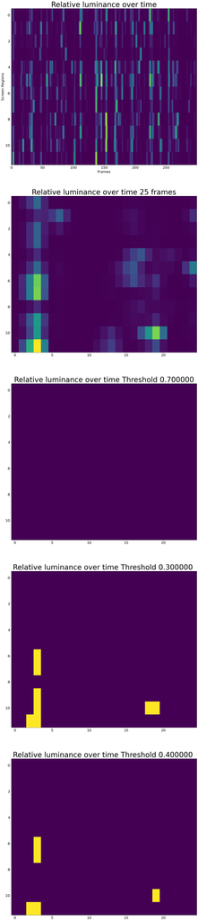

```python
showflash(flasvid,0,25)
```

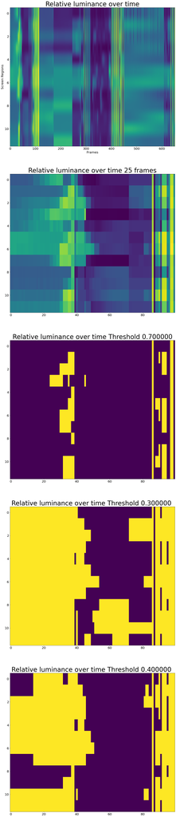

```python
showflash(pory,0,100)
```

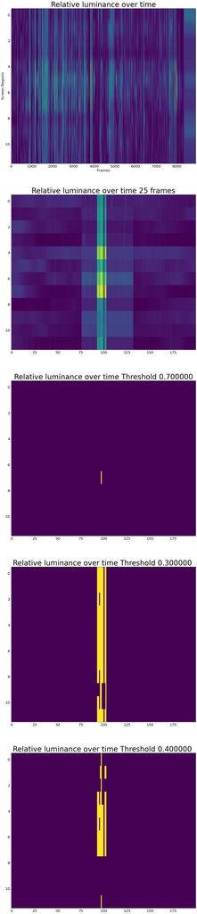

```python
showflash(alien_flashes,200,400)
```

## Future Work

Currently, I am working on identifying specific timestamps where the flashes happen.

For each frame in each segment, I will: • Check for changes in relative luminance using a threshold greater than 10% of the maximum luminance • Check how many regions of the screen are above that threshold. • If there are three or more frames in the segment that is flashing I will mark the timestamp of that segment as a dangerous flash.